# statistics

### Lachin Naghashyar - 98110179

## Q1: Working with data in R environment

### a: consider Chi-Square distribution

#### i: The density function of it is shown below:

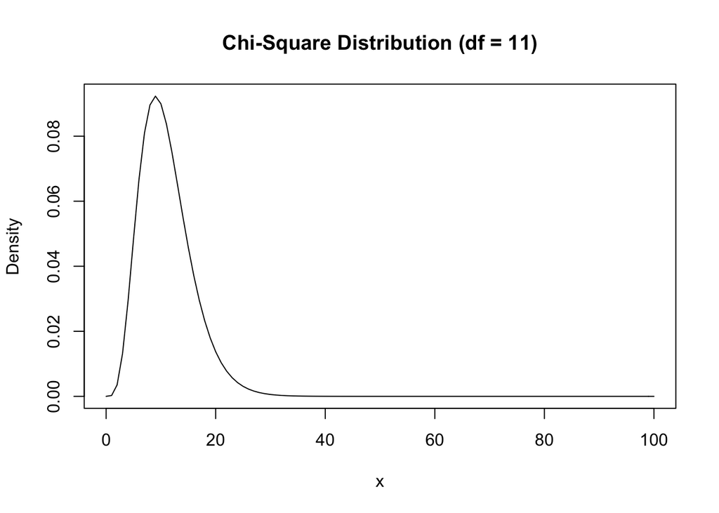

```r
curve(dchisq(x, df = 11), from = 0, to = 100,
      main = 'Chi-Square Distribution (df = 11)', #title
      ylab = 'Density')
```

#### ii: Let’s produce n = 10, 100 and 1000 samples of size 50 from this distribution. To do so, we generate n * 50 samples and store them in a matrix with n rows and 50 columns.

##### for n = 10:

```r
samples_1 = rchisq(500, df = 11)
matrix_1 =  matrix(samples_1, nrow = 10, ncol = 50)
```

##### for n = 100:

```r
samples_2 = rchisq(5000, df = 11)
matrix_2 =  matrix(samples_2, nrow = 100, ncol = 50)
```

##### for n = 1000:

```r
samples_3 = rchisq(50000, df = 11)
matrix_3 =  matrix(samples_3, nrow = 1000, ncol = 50)
```

##### Then calculate the means of each of them and plot their histograms (note that we should calculate the sample means of each row):

```r
means_1 = apply(matrix_1, 1, mean) # use 1 to apply it row wise
means_2 = apply(matrix_2, 1, mean)
means_3 = apply(matrix_3, 1, mean)
```

##### plot the histograms with hist function

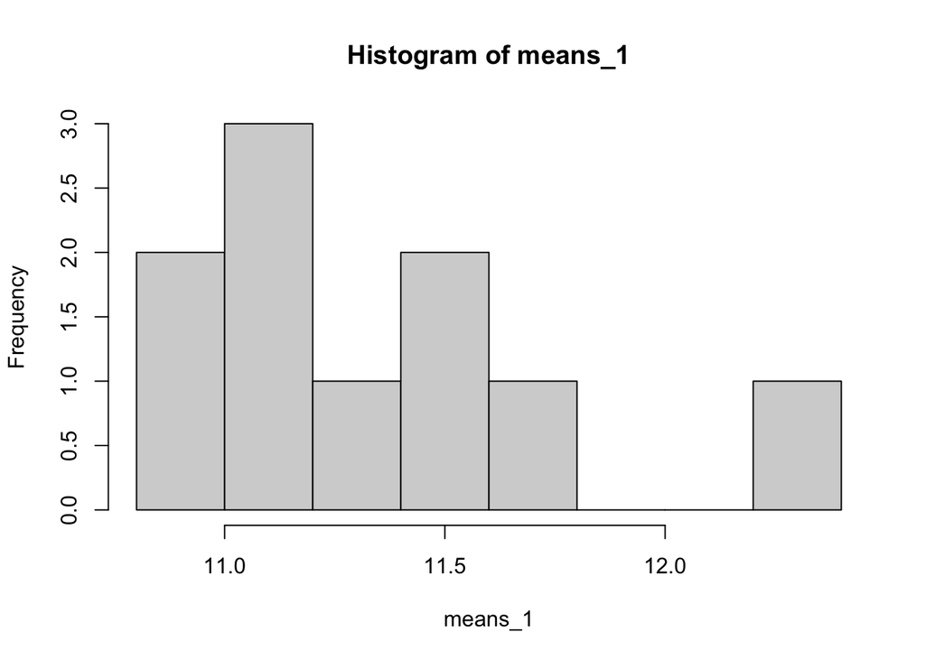

```r
hist(means_1)
```

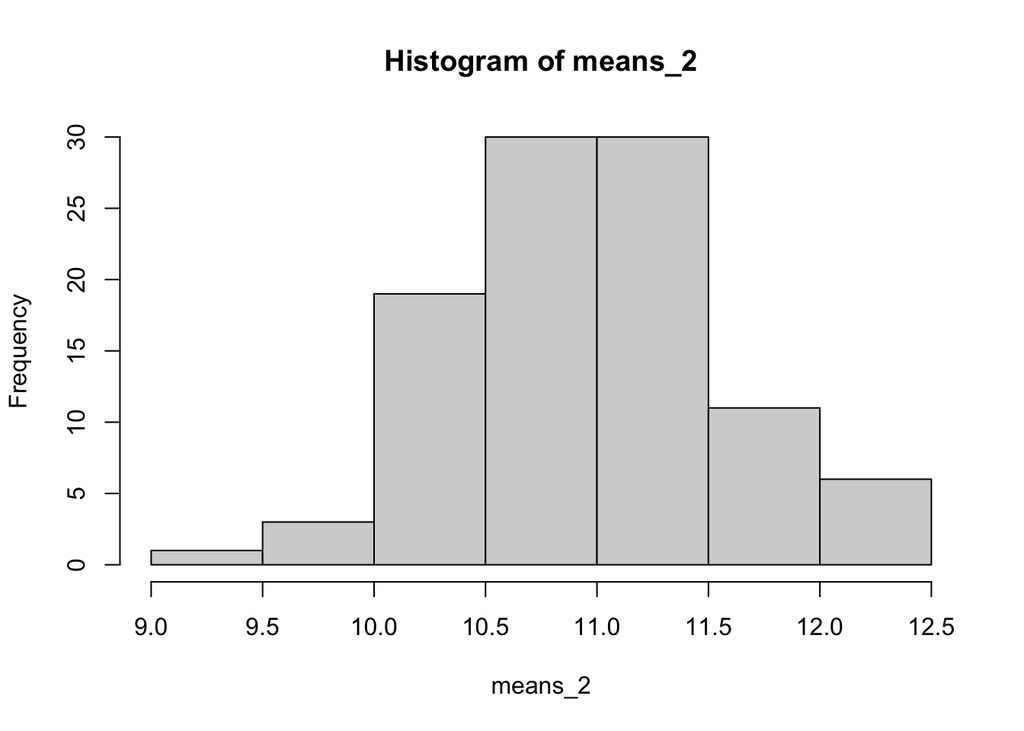

```r
hist(means_2)
```

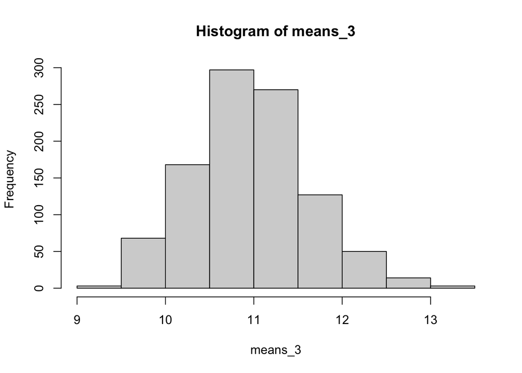

```r
hist(means_3)
```

#### iii: Let’s calculate the mean and variance of these samples and compare the histogram of their means with the normal distribution:

```r
mean_1 = mean(means_1)
mean_2 = mean(means_2)
mean_3 = mean(means_3)
mean_1
```

```
## [1] 11.35438
```

```r
mean_2
```

```
## [1] 10.95677
```

```r
mean_3
```

```
## [1] 10.96955
```

```r
var_1 = var(means_1)
var_2 = var(means_2)
var_3 = var(means_3)
var_1
```

```
## [1] 0.1773958
```

```r
var_2
```

```
## [1] 0.386994
```

```r
var_3
```

```
## [1] 0.424945
```

##### Next, normalize the means:

```r
normalized_mean_1 = (means_1 - mean_1)/sqrt(var_1)
normalized_mean_2 = (means_2 - mean_2)/sqrt(var_2)
normalized_mean_3 = (means_3 - mean_3)/sqrt(var_3)
```

##### comapre their histogram with the normal dirtribution’s hist:

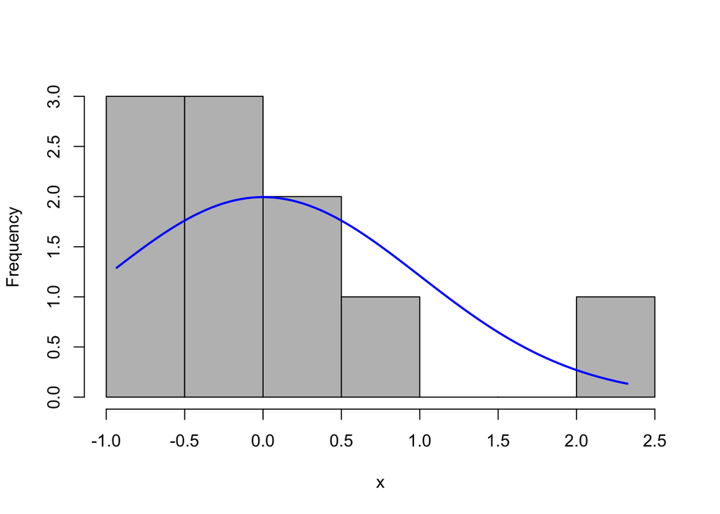

```r
#hist(normalized_mean_1)
#lines(seq(-2, 1.5, by=.001), dnorm(seq(-2, 1.5, by=.001), mean_1, sqrt(var_1)), col="blue")
#hist(normalized_mean_2)
#lines(seq(-3, 2.5, by=.1), dnorm(seq(-3, 2.5, by=.1), mean_2, sqrt(var_2)), col="blue")
#hist(normalized_mean_3)
#lines(seq(-4, 4, by=.1), dnorm(seq(-4, 4, by=.1), mean_3, sqrt(var_3)), col="blue")
plotNormalHistogram( normalized_mean_1, prob = FALSE, length = 1000 )
```

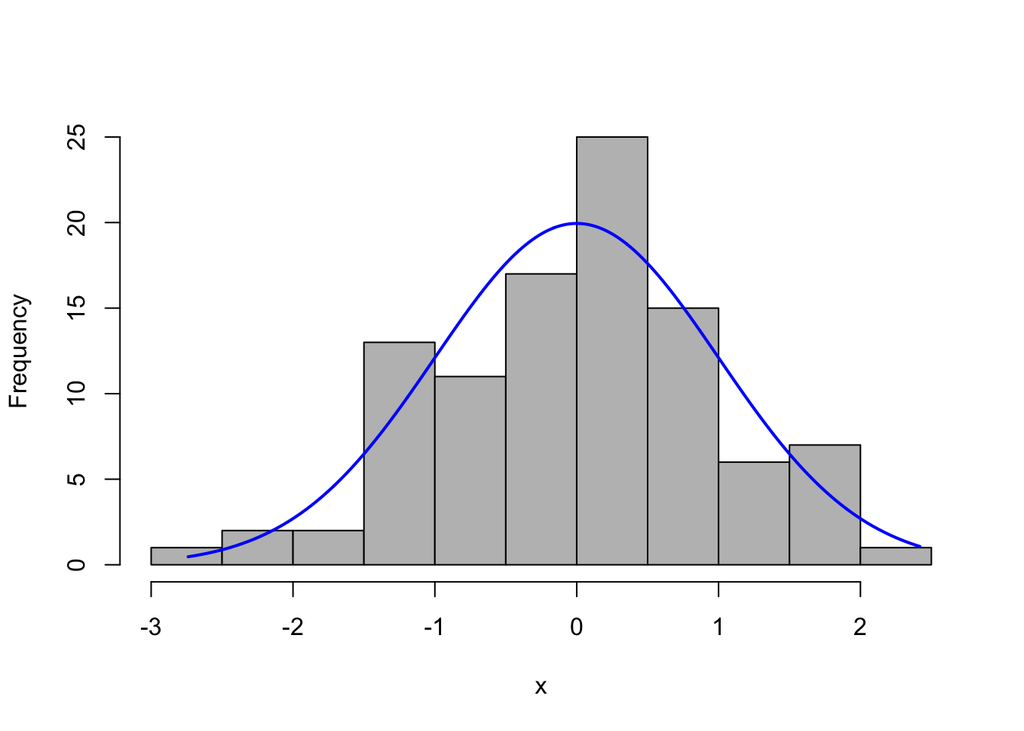

```r
plotNormalHistogram( normalized_mean_2, prob = FALSE, length = 1000 )
```

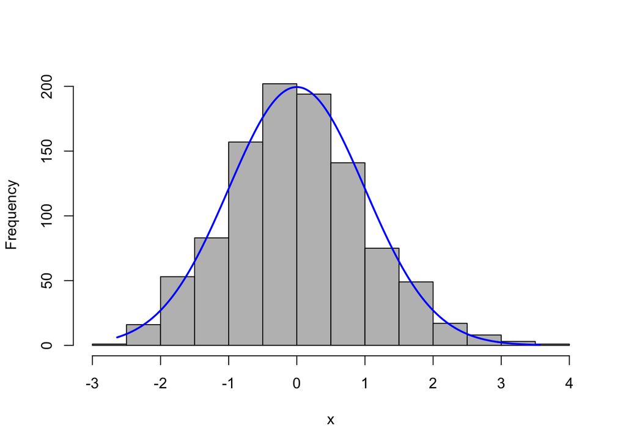

```r
plotNormalHistogram( normalized_mean_3, prob = FALSE, length = 1000 )
```

##### we can see that as the n gets larger, the corresponding histogram gets more similar to the histogram of normal distribution. This results is aligned with the central limit theorem which states that if you have a population with mean μ and standard deviation σ and take sufficiently large random samples from the population with replacement , then the distribution of the sample means will be approximately normally distributed.

### b: consider the Births data set from fastR2 package (contains information about the number of birth in each day during a time interval of 20 years in America)

#### i: Find the days with least and most number of average births:

##### first let’s view Births

```r
View(Births)
```

##### we can see that it has a column births and data in it. We iterate over the days in those years, find the mean number of births and use which to indicate the place min/max occurs.

```r
days_avr <- matrix(0, 1, 365)
for (i in 1:365) {
  days_avr[i] = mean(Births$births[Births$day_of_year == i])
}

which.min(days_avr)
```

```
## [1] 360
```

```r
which.max(days_avr)
```

```
## [1] 260
```

#### the mean value of each month is obtained as follows:

```r
months_means <- matrix(0, 1, 12)
for (i in 1:12) {
  months_means[i] = mean(Births$births[Births$month == i])
}
months_means
```

```
##          [,1]     [,2]     [,3]     [,4] [,5]     [,6]     [,7]     [,8]
## [1,] 9288.976 9491.301 9464.742 9267.958 9331 9597.618 10032.73 10177.04
##          [,9]    [,10]    [,11]    [,12]
## [1,] 10343.29 9766.729 9492.122 9523.187
```

##### also lets sort the array obove (ascending):

```r
order(months_means)
```

```
##  [1]  4  1  5  3  2 11 12  6 10  7  8  9
```

##### to have it descending consider

```r
order(-months_means)
```

```
##  [1]  9  8  7 10  6 12 11  2  3  5  1  4
```

#### also find the average value of each year this way:

```r
years_avr <- matrix(0, 1, 20)

for (i in 1:20) {
  years_avr[i] = mean(Births$births[Births$year == i + 1968])
}
years_avr
```

```
##          [,1]    [,2]     [,3]     [,4]     [,5]    [,6]     [,7]     [,8]
## [1,] 9859.118 10231.8 9761.847 8923.123 8618.274 8685.77 8639.359 8678.322
##          [,9]    [,10]    [,11]    [,12]    [,13]    [,14]    [,15]    [,16]
## [1,] 9128.899 9145.745 9588.321 9885.104 9960.219 10096.92 9980.085 10036.97
##         [,17]    [,18]    [,19]   [,20]
## [1,] 10315.22 10303.24 10447.15 10693.4
```

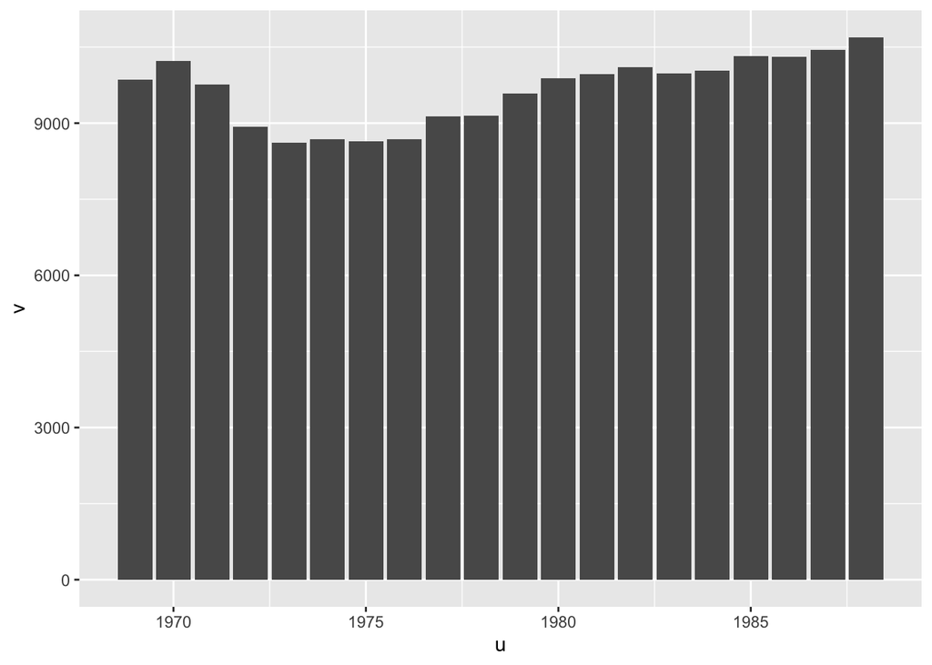

```r
# plot the result
ggplot(data=data.frame(u=1969:1988,v=as.vector(years_avr))
       ,aes(x=u,y=v))+geom_bar(stat = "identity")
```

### c: consider the storms data set from dplyr package.

```r
View(storms)
```

#### sort them based on the time they occured and save them in a file (q1_3.txt)

```r
sorted =
  storms[with(storms, order(storms$year, storms$month, storms$day , storms$hour)),]
sorted
```

```
## # A tibble: 10,010 × 13
##    name   year month   day  hour   lat  long status      category  wind pressure
##    <chr> <dbl> <dbl> <int> <dbl> <dbl> <dbl> <chr>       <ord>    <int>    <int>
##  1 Amy    1975     6    27     0  27.5 -79   tropical d… -1          25     1013
##  2 Amy    1975     6    27     6  28.5 -79   tropical d… -1          25     1013
##  3 Amy    1975     6    27    12  29.5 -79   tropical d… -1          25     1013
##  4 Amy    1975     6    27    18  30.5 -79   tropical d… -1          25     1013
##  5 Amy    1975     6    28     0  31.5 -78.8 tropical d… -1          25     1012
##  6 Amy    1975     6    28     6  32.4 -78.7 tropical d… -1          25     1012
##  7 Amy    1975     6    28    12  33.3 -78   tropical d… -1          25     1011
##  8 Amy    1975     6    28    18  34   -77   tropical d… -1          30     1006
##  9 Amy    1975     6    29     0  34.4 -75.8 tropical s… 0           35     1004
## 10 Amy    1975     6    29     6  34   -74.8 tropical s… 0           40     1002
## # … with 10,000 more rows, and 2 more variables: ts_diameter <dbl>,
## #   hu_diameter <dbl>
```

```r
write.table(sorted, file="q1_3.txt", append = FALSE, sep = " ", dec = ".",
            row.names = TRUE, col.names = TRUE)
```

#### plot the coordinates (lat, long) of the place storms occurred

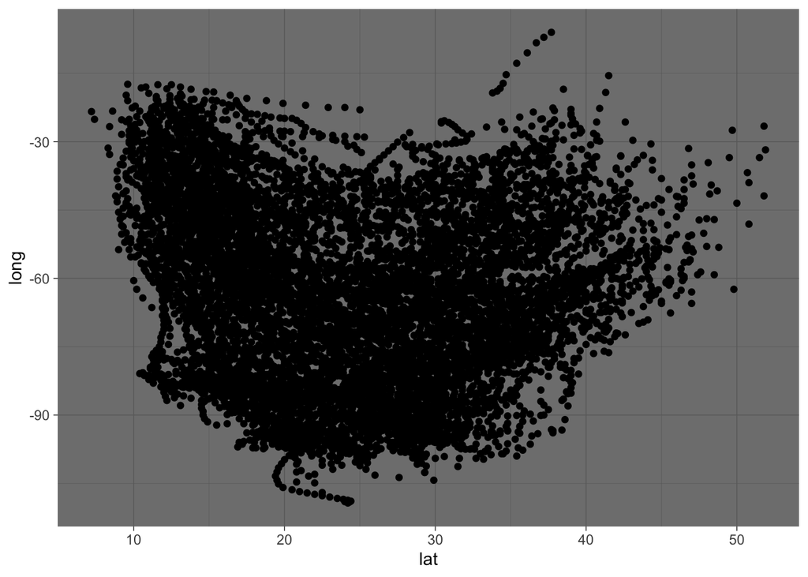

```r
p=ggplot(data=storms)+geom_point(aes(lat,long))
p+theme_dark()
```

```r
#map <- get_stamenmap(bbox = c(left= -11 , bottom = -11 , right = 11 , top = -11 ), maptype = "terrain" , zoom = 5)
```

#### also color them based on the status

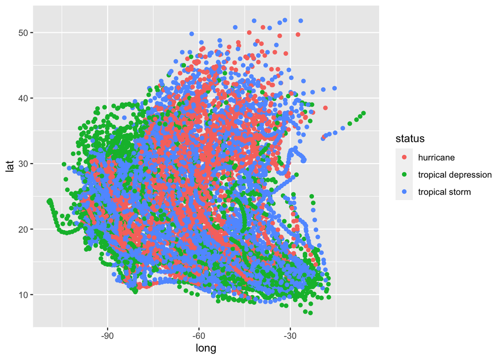

```r
ggplot(data = storms)+geom_point(mapping = aes(x=long,y=lat,color=status))
```

## Q2: Heart Attack Prevention

### a: Loading the data set and getting it ready

#### load the data set from “had.txt”

```r
heartAttackData <- read.delim("had.txt", header=F)
```

#### i: Separate the last(result) column and store it in a variable called label. Store the first 6 columns as features.

```r
label = heartAttackData[,ncol(heartAttackData)]
features = heartAttackData[,1:6]
```

#### ii: separate the data into test(20%) and train(80%) sets.

```r
n = length(label)
test_ind <- sample(1:n, as.integer(n * 0.2))
test_label = label[test_ind]
test_feature = features[test_ind,]
train_label = label[-test_ind]
train_feature = features[-test_ind,]
```

#### save test and train sets in separate files

```r
write.table(test_label, file="test_label.txt")
write.table(test_feature, file="test_feature.txt")
write.table(train_label, file="train_label.txt")
write.table(train_feature, file="train_feature.txt")
```

### b: regresssion

#### i: use the train data set and apply regression on them to obtain the corresponding coefficients.

```r
model <- lm(as.vector(train_label) ~  as.vector(train_feature[,1]) + as.vector(train_feature[,2]) + as.vector(train_feature[,3]) + as.vector(train_feature[,4]) + as.vector(train_feature[,5]) + as.vector(train_feature[,6]))
summary(model)
```

```
##
## Call:
## lm(formula = as.vector(train_label) ~ as.vector(train_feature[,
##     1]) + as.vector(train_feature[, 2]) + as.vector(train_feature[,
##     3]) + as.vector(train_feature[, 4]) + as.vector(train_feature[,
##     5]) + as.vector(train_feature[, 6]))
##
## Residuals:
##      Min       1Q   Median       3Q      Max
## -2.15053 -0.64135 -0.04023  0.65443  1.90446
##
## Coefficients:
##                                 Estimate Std. Error t value Pr(>|t|)
## (Intercept)                    2.2696296  0.5196336   4.368 1.88e-05 ***
## as.vector(train_feature[, 1]) -0.0233198  0.0063140  -3.693 0.000275 ***
## as.vector(train_feature[, 2]) -0.6033643  0.1177786  -5.123 6.25e-07 ***
## as.vector(train_feature[, 3])  0.3924100  0.0529861   7.406 2.30e-12 ***
## as.vector(train_feature[, 4]) -0.0056616  0.0031386  -1.804 0.072524 .
## as.vector(train_feature[, 5]) -0.0005516  0.0010714  -0.515 0.607163
## as.vector(train_feature[, 6]) -0.0294878  0.1561733  -0.189 0.850400
## ---
## Signif. codes:  0 '***' 0.001 '**' 0.01 '*' 0.05 '.' 0.1 ' ' 1
##
## Residual standard error: 0.8366 on 236 degrees of freedom
## Multiple R-squared:  0.3151, Adjusted R-squared:  0.2977
## F-statistic: 18.09 on 6 and 236 DF,  p-value: < 2.2e-16
```

##### Call: shows us the formula that R used to fit the regression model. label is our dependent variable and we are using the 6 features as independent variables (to predict).

##### Residuals: The residuals are the difference between the actual values and the predicted ones. we’d definitely want our median value to be centered around zero as this would tell us our residuals were somewhat symmetrical and that our model was predicting evenly at both the high and low ends of our dataset. Looking at the output above, it looks like our distribution is slightly right-skewed but again it is also near 0 so we can be hopeful that our model is predicting quite well.

##### Coefficients: These are estimations of coefficients in the equation of form $label=c_1 * f_1+c_2 * f_2+c_3 * f_3+c_4 * f_4+c_5 * f_5+c_6 * f_6+c_7$, where $c_7$ is the intercept and $c_i$s are the coefficient(slope) of each factor. Because we often don’t have enough information or data to know the exact equation that exists in the wild, we have to build this equation by generating estimates for both the slopes and the intercept. These estimates are most often generated through the ordinary least squares (where regression model finds the line that fits the points in such a way that it minimizes the distance between each point and the line).

###### Coefficients — Std. Error: The standard error of the coefficient is an estimate of the standard deviation of the coefficient. In effect, it is telling us how much uncertainty there is with our coefficient. The standard error is often used to create confidence intervals.

###### Coefficients — t value: The t-statistic is simply the coefficient divided by the standard error. In general, we want our coefficients to have large t-statistics.

###### Coefficients — Pr(>|t|) and Signif. codes The p-value is calculated using the t-statistic from the T distribution. The p-value, in association with the t-statistic, help us to understand how significant our coefficient is to the model. In practice, any p-value below 0.05 is usually deemed as significant. The coefficient codes give us a quick way to visually see which coefficients are significant to the model.

##### Residual standard error: The residual standard error is a measure of how well the model fits the data.The residual standard error tells us the average amount that the actual values of Y differ from the predictions. In general, we want the smallest residual standard error possible.

##### Multiple R-squared and Adjusted R-squared: The Multiple R-squared value is most often used for simple linear regression (one predictor). It tells us what percentage of the variation within our dependent variable that the independent variable is explaining. it’s another method to determine how well our model is fitting the data. The Adjusted R-squared value is used when running multiple linear regression and can conceptually be thought of in the same way we described Multiple R-squared. The Adjusted R-squared value shows what percentage of the variation within our dependent variable that all predictors are explaining.

##### The F-statistic and overall p-value help us determine the result of this test. If you have a lot of independent variables, it’s common for an F-statistic to be close to one and to still produce a p-value where we would reject the null hypothesis. However, for smaller models, a larger F-statistic generally indicates that the null hypothesis should be rejected.

#### ii: Identify the importance of coeffs:

##### Although the coeffs show us the amount of importance, we can not just compare their amounts with each other since they don’t have the same scales they are not scaled the same. We should first normalize them (for example between 0 and 1) and then compare them with each other.

##### Regression analysis is a form of inferential statistics. The p-values help determine whether the relationships that you observe in your sample also exist in the larger population. The p-value for each independent variable tests the null hypothesis that the variable has no correlation with the dependent variable. If there is no correlation, there is no association between the changes in the independent variable and the shifts in the dependent variable.

##### If the p-value for a variable is less than your significance level, your sample data provide enough evidence to reject the null hypothesis for the entire population. On the other hand, a p-value that is greater than the significance level indicates that there is insufficient evidence in your sample to conclude that a non-zero correlation exists.

##### Recall the p-value in the coefficients part for our example:

```r
summary(model)
```

```
##
## Call:
## lm(formula = as.vector(train_label) ~ as.vector(train_feature[,
##     1]) + as.vector(train_feature[, 2]) + as.vector(train_feature[,
##     3]) + as.vector(train_feature[, 4]) + as.vector(train_feature[,
##     5]) + as.vector(train_feature[, 6]))
##
## Residuals:
##      Min       1Q   Median       3Q      Max
## -2.15053 -0.64135 -0.04023  0.65443  1.90446
##
## Coefficients:
##                                 Estimate Std. Error t value Pr(>|t|)
## (Intercept)                    2.2696296  0.5196336   4.368 1.88e-05 ***
## as.vector(train_feature[, 1]) -0.0233198  0.0063140  -3.693 0.000275 ***
## as.vector(train_feature[, 2]) -0.6033643  0.1177786  -5.123 6.25e-07 ***
## as.vector(train_feature[, 3])  0.3924100  0.0529861   7.406 2.30e-12 ***
## as.vector(train_feature[, 4]) -0.0056616  0.0031386  -1.804 0.072524 .
## as.vector(train_feature[, 5]) -0.0005516  0.0010714  -0.515 0.607163
## as.vector(train_feature[, 6]) -0.0294878  0.1561733  -0.189 0.850400
## ---
## Signif. codes:  0 '***' 0.001 '**' 0.01 '*' 0.05 '.' 0.1 ' ' 1
##
## Residual standard error: 0.8366 on 236 degrees of freedom
## Multiple R-squared:  0.3151, Adjusted R-squared:  0.2977
## F-statistic: 18.09 on 6 and 236 DF,  p-value: < 2.2e-16
```

### b: evaluate the coeffs on test set

#### apply the coeffs on test:

```r
test_result = test_feature[,1]*model$coefficients[2] + test_feature[,2]*model$coefficients[3] +
              test_feature[,3]*model$coefficients[4] + test_feature[,4]*model$coefficients[5] +
              test_feature[,5]*model$coefficients[6] + test_feature[,6]*model$coefficients[7] + model$coefficients[1]
test_result
```

```
##  [1]  0.308760421  0.017511325 -0.629110014  1.282161918  0.371686136
##  [6]  0.411184529  0.571192256  0.600307543  0.340758571  0.179946482
## [11]  0.123305173 -0.579049347  0.152050763 -0.256057750  0.389446441
## [16]  0.681983587 -0.459635503 -0.113511656  0.334148059 -0.514178899
## [21] -0.507111894 -0.663048115  0.640923143  0.672923864  0.346294511
## [26] -0.441766744 -0.599861067  0.902624492 -0.007497851 -0.674664425
## [31] -0.582934530 -0.764073574 -0.633125885 -0.561240818  0.560483690
## [36]  0.173625097  0.238471890  0.882335003  1.393631381 -0.104439993
## [41]  0.828994861  0.857393274 -0.464210238  0.301965933 -0.488469698
## [46] -0.626547287  0.018579858 -0.371003369 -0.056802380 -0.664444329
## [51]  1.242324541 -0.471232420  0.363948587 -0.602993066  0.313947109
## [56] -0.121110946  0.336569581 -0.018839080 -0.561495187  1.047402380
```

```r
apply_limit <- function(result, limit){
  result[result > limit] = 1
  result[result <= limit] = -1
  return(result)
}
res_0 = apply_limit(test_result, limit = 0)
res_0
```

```
##  [1]  1  1 -1  1  1  1  1  1  1  1  1 -1  1 -1  1  1 -1 -1  1 -1 -1 -1  1  1  1
## [26] -1 -1  1 -1 -1 -1 -1 -1 -1  1  1  1  1  1 -1  1  1 -1  1 -1 -1  1 -1 -1 -1
## [51]  1 -1  1 -1  1 -1  1 -1 -1  1
```

##### compare the test_result with actual labels to see how many are correct:

```r
check_correctness <- function(result){
  corrects = 0
  for (i in 1:length(result)) {
    if (result[i] == test_label[i]) {
      corrects = corrects + 1
    }
  }
  return(corrects/length(result))
}

check_correctness(res_0)
```

```
## [1] 0.7833333
```

#### ii: find the maximum correcness rate for different values of limit in [-2, 2]:

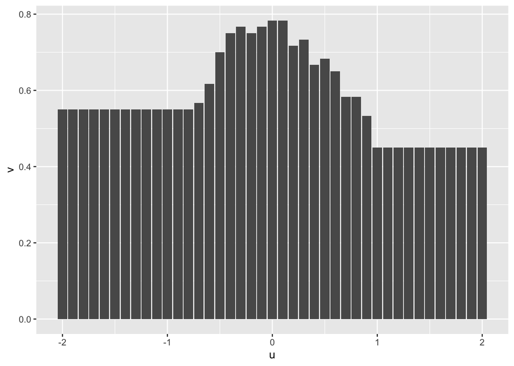

```r
limit_seq = seq(-2, 2, by = 0.1)
fracs = c()
max_limit = 0
max_val = 0
for (i in limit_seq){
  frac = check_correctness(apply_limit(test_result, limit = i))
  fracs = c(fracs, frac)
  if (frac > max_val) {
    max_val = frac
    max_limit = i
  }
}

ggplot(data=data.frame(u=as.vector(limit_seq),v=fracs)
       ,aes(x=u,y=v))+geom_bar(stat = "identity")
```

```r
print(max_val)
```

```
## [1] 0.7833333
```

```r
print(max_limit)
```

```
## [1] 0
```

##### hence we can see that the max occurs around zero.

## Q3

### a:

```r
# read data from the file:
housing_data <- read_excel("housing.xlsx", sheet = "price of land")
```

```
## * `` -> ...4
## * `` -> ...5
## * `` -> ...6
## * `` -> ...8
## * `` -> ...9
## * ...
```

#### i: I started by calculating all the invalid entries in each column(the ones that were not in a numeric format or where NA or zero). Then I ignored the columns with large number of undefined entries(NAs). I used a threshold of 5 and deleted those columns using subset function. Also, for all the cells with a wrong format, I changed their contents to be NA. This way, they will get ignored in upcoming calculations.

```r
invalid_ones <- matrix(0, 1, ncol(housing_data))
for (i in 2: ncol(housing_data)){
  invalid_ones[i] = 0
  for (j in 3: nrow(housing_data)){
    if (is.na(suppressWarnings(as.numeric(as.character(housing_data[j, i])))) | is.na(housing_data[j, i]) | suppressWarnings(housing_data[j, i]==0)){
      invalid_ones[i] = invalid_ones[i] + 1
      housing_data[j, i] = NA
    }
  }
}
invalid_ones
```

```
##      [,1] [,2] [,3] [,4] [,5] [,6] [,7] [,8] [,9] [,10] [,11] [,12] [,13] [,14]
## [1,]    0    0    0    0    2    0    0    0    1     0     0     0     1     2
##      [,15] [,16] [,17] [,18] [,19] [,20] [,21] [,22] [,23] [,24] [,25] [,26]
## [1,]     0     0     0     0     0     0     0     0     0     0     0     0
##      [,27] [,28] [,29] [,30] [,31] [,32] [,33] [,34] [,35] [,36] [,37] [,38]
## [1,]     0     0     0     0     0     1     0     0     0     1     1     4
##      [,39] [,40] [,41] [,42] [,43] [,44] [,45] [,46]
## [1,]     4     6    13     9    19    18    19     8
```

```r
print(as.vector(which(invalid_ones > 5)))
```

```
## [1] 40 41 42 43 44 45 46
```

```r
housing_data = subset(housing_data, select = -as.vector(which(invalid_ones > 5)))

# iii: save the modified data set to a new file
write_xlsx( housing_data,
            path = "housing_modified.xlsx",
            col_names = TRUE,
            format_headers = TRUE,
            use_zip64 = FALSE)
```

#### ii: The reason why I decided to delete some of the columns and cells instead of substituting them with mean or similar data, was that when a data is unknown its better to ignore it. Specially that we have a large amount of data and ignoring a fraction of them wouldn’t hurt so much. Also when too much data is missing for a variable, it’s better to delete the variable, which was the case for the last columns. More on this topic can be found [here](https://towardsdatascience.com/all-about-missing-data-handling-b94b8b5d2184):

### b:

```r
k = 98110179%%22
k
```

```
## [1] 13
```

```r
price = housing_data[k+3, -1]
time = rev(seq(2, 39, by=1))

model <- lm(as.numeric(price) ~  time)
summary(model)
```

```
##
## Call:
## lm(formula = as.numeric(price) ~ time)
##
## Residuals:
##    Min     1Q Median     3Q    Max
## -33045 -18518   1686  12373  74637
##
## Coefficients:
##             Estimate Std. Error t value Pr(>|t|)
## (Intercept)  -6229.0     8341.2  -0.747     0.46
## time          2671.2      363.2   7.355 1.34e-08 ***
## ---
## Signif. codes:  0 '***' 0.001 '**' 0.01 '*' 0.05 '.' 0.1 ' ' 1
##
## Residual standard error: 24180 on 35 degrees of freedom
##   (1 observation deleted due to missingness)
## Multiple R-squared:  0.6071, Adjusted R-squared:  0.5959
## F-statistic: 54.09 on 1 and 35 DF,  p-value: 1.339e-08
```

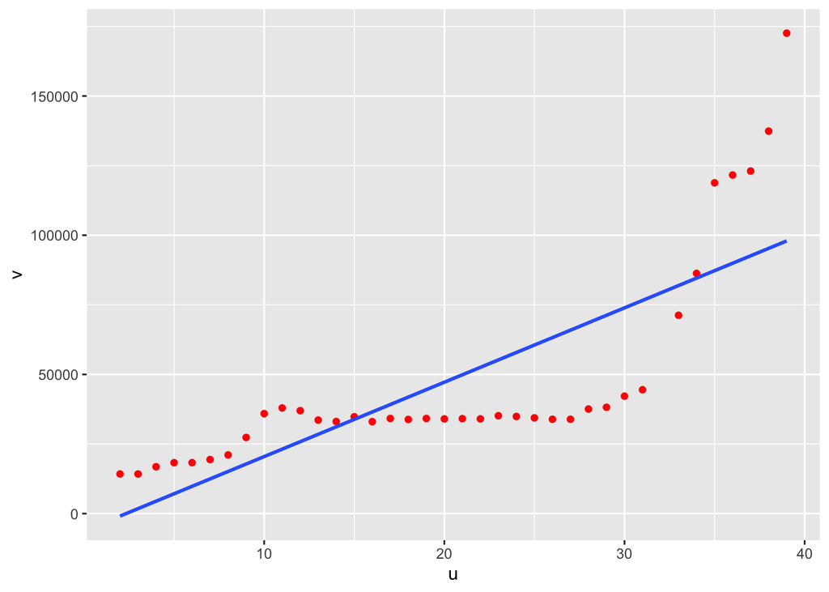

```r
ggplot(data=data.frame(u=time,v=as.numeric(price)), aes(x=u,y=v)) +
  geom_point(color='red') +
  geom_smooth(method = "lm", se = FALSE)
```

```r
price = housing_data[-1, -1]
time = rev(seq(2, 39, by=1))
district = seq(2, 24, by=1)
times = c()
districts = c()
prices = c()

for (d in district){
  for (t in time){
    districts = c(districts, d)
    prices = c(prices, as.numeric(housing_data[d, t]))
  }
  times = c(times, as.vector(time))
}


model <- lm(prices ~  times + districts)
summary(model)
```

```
##
## Call:
## lm(formula = prices ~ times + districts)
##
## Residuals:
##    Min     1Q Median     3Q    Max
## -84339 -29152  -7844  16866 388060
##
## Coefficients:
##             Estimate Std. Error t value Pr(>|t|)
## (Intercept) 189545.4     5069.7   37.39   <2e-16 ***
## times        -3669.9      161.8  -22.69   <2e-16 ***
## districts    -4205.0      264.6  -15.89   <2e-16 ***
## ---
## Signif. codes:  0 '***' 0.001 '**' 0.01 '*' 0.05 '.' 0.1 ' ' 1
##
## Residual standard error: 51430 on 854 degrees of freedom
##   (17 observations deleted due to missingness)
## Multiple R-squared:  0.4721, Adjusted R-squared:  0.4709
## F-statistic: 381.9 on 2 and 854 DF,  p-value: < 2.2e-16
```

```r
time = rev(seq(2, 39, by=1))
district = seq(1, 23, by=1)
df = data.frame(p=prices, t=times)
zeros = integer(length(prices))
t = length(time)
for (d in district) {
  if (d != k+2) {
    d_i = zeros
    s = (d-1)*t
    e = d*t
    d_i[s:e] = d_i[s:e] + 1
    df[paste0("dist",d)] = d_i
  }
}
```

```r
model <- lm(p~., df)
summary(model)
```

```
##
## Call:
## lm(formula = p ~ ., data = df)
##
## Residuals:
##    Min     1Q Median     3Q    Max
## -69913 -30446  -6765  20371 268746
##
## Coefficients:
##             Estimate Std. Error t value Pr(>|t|)
## (Intercept)    86416       7239  11.937  < 2e-16 ***
## t              -3517        143 -24.599  < 2e-16 ***
## dist1          49615       9428   5.263 1.81e-07 ***
## dist2         111514       9269  12.031  < 2e-16 ***
## dist3         109142       9271  11.773  < 2e-16 ***
## dist4         124605       9271  13.441  < 2e-16 ***
## dist5          76508       9271   8.253 6.04e-16 ***
## dist6          60031       9271   6.475 1.62e-10 ***
## dist7          93635       9271  10.100  < 2e-16 ***
## dist8          68154       9271   7.351 4.69e-13 ***
## dist9          55255       9271   5.960 3.72e-09 ***
## dist10         24259       9584   2.531 0.011555 *
## dist11         26810       9271   2.892 0.003930 **
## dist12         25882       9271   2.792 0.005362 **
## dist13         20322       9268   2.193 0.028613 *
## dist14         44000       9365   4.698 3.07e-06 ***
## dist16         17634       9440   1.868 0.062110 .
## dist17         17751       9423   1.884 0.059941 .
## dist18          8595       9508   0.904 0.366285
## dist19          9852       9271   1.063 0.288239
## dist20         10348       9569   1.081 0.279799
## dist21          5189       9272   0.560 0.575867
## dist22         20186       9398   2.148 0.032017 *
## dist23         33608       9366   3.588 0.000352 ***
## ---
## Signif. codes:  0 '***' 0.001 '**' 0.01 '*' 0.05 '.' 0.1 ' ' 1
##
## Residual standard error: 44760 on 833 degrees of freedom
##   (17 observations deleted due to missingness)
## Multiple R-squared:  0.6101, Adjusted R-squared:  0.5993
## F-statistic: 56.67 on 23 and 833 DF,  p-value: < 2.2e-16
```

#### iv: The second approach is better. Because in the first one, we used numbers to indicate the district and also applied that number to the regression we used. Since there isn’t any meaningful relation between a district and its number(name), it’s better to keep its number out of our calculations. Hence, using separate indicators for each district, results in more reliable results. Moreover, we know that the Adjusted R-squared reflects the fit of the model, where a higher value generally indicates a better fit. We can see that it is higher in the second part, meaning it has generated a better fit.

### c:

```r
k = 98110179%%33
k
```

```
## [1] 24
```

#### i:

##### winter of 90 is 0 since it is in the 35th column, we find th kth and kth+1 seasons using that:

```r
x_i = as.numeric(unlist(housing_data[-1,35-k]))
y_i = as.numeric(unlist(housing_data[-1,35-k-1]))
```

##### calculate their means and variance:

```r
print(mean(x_i))
```

```
## [1] 53664.19
```

```r
print(mean(y_i))
```

```
## [1] 55482.62
```

```r
print(paste("difference between means", mean(x_i) - mean(y_i)))
```

```
## [1] "difference between means -1818.42507108178"
```

```r
print(var(x_i))
```

```
## [1] 1080633587
```

```r
print(var(y_i))
```

```
## [1] 1087871103
```

##### find t and p values:

```r
print(t.test(x_i, y_i))
```

```
##
##  Welch Two Sample t-test
##
## data:  x_i and y_i
## t = -0.18727, df = 44, p-value = 0.8523
## alternative hypothesis: true difference in means is not equal to 0
## 95 percent confidence interval:
##  -21387.52  17750.67
## sample estimates:
## mean of x mean of y
##  53664.19  55482.62
```

```r
z_i = x_i - y_i
print(t.test(z_i))
```

```
##
##  One Sample t-test
##
## data:  z_i
## t = -6.9218, df = 22, p-value = 5.977e-07
## alternative hypothesis: true mean is not equal to 0
## 95 percent confidence interval:
##  -2363.249 -1273.602
## sample estimates:
## mean of x
## -1818.425
```

```r
z_i = x_i - y_i

denum = sqrt(var(z_i) / length(z_i))

p_value = pt(q = mean(z_i) / denum , df = length(z_i) - 1, lower.tail = T)
print(p_value)
```

```
## [1] 2.988351e-07
```

##### In this case, we can see that it has a much lower p-value which results in the rejection of the null hypothesis.

##### The second approach is better because our goal is to evaluate the difference of prices in two consecutive seasons and by subtracting those two from each other, we are canceling out the role of districts (we don’t want the effect of having differences between districts). Hence, it gives us a better results and the p-value is much lower.